# Risk Factor Analysis

## Outcome Variable

**Outcome Variable:** ever_co

## Predictor Variables

**Intervention Variable:** birthlen

**Adjustment Set:**

- arm
- sex
- W_mage
- meducyrs
- feducyrs
- vagbrth
- single
- brthmon
- W_parity
- delta_W_mage
- delta_meducyrs
- delta_feducyrs
- delta_vagbrth
- delta_single
- delta_brthmon
- delta_W_parity

## Stratifying Variables

The analysis was stratified on these variable(s):

- agecat
- studyid
- country

## Data Summary

| agecat | studyid | country | birthlen | ever_co | n_cell | n |
| --- | --- | --- | --- | --- | --- | --- |
| 0-24 months | ki0047075b-MAL-ED | BANGLADESH | >=50 cm | 0 | 26 | 256 |
| 0-24 months | ki0047075b-MAL-ED | BANGLADESH | >=50 cm | 1 | 3 | 256 |
| 0-24 months | ki0047075b-MAL-ED | BANGLADESH | <48 cm | 0 | 117 | 256 |
| 0-24 months | ki0047075b-MAL-ED | BANGLADESH | <48 cm | 1 | 25 | 256 |
| 0-24 months | ki0047075b-MAL-ED | BANGLADESH | [48-50) cm | 0 | 76 | 256 |
| 0-24 months | ki0047075b-MAL-ED | BANGLADESH | [48-50) cm | 1 | 9 | 256 |
| 0-24 months | ki0047075b-MAL-ED | BRAZIL | >=50 cm | 0 | 34 | 191 |
| 0-24 months | ki0047075b-MAL-ED | BRAZIL | >=50 cm | 1 | 0 | 191 |
| 0-24 months | ki0047075b-MAL-ED | BRAZIL | <48 cm | 0 | 79 | 191 |
| 0-24 months | ki0047075b-MAL-ED | BRAZIL | <48 cm | 1 | 1 | 191 |
| 0-24 months | ki0047075b-MAL-ED | BRAZIL | [48-50) cm | 0 | 76 | 191 |
| 0-24 months | ki0047075b-MAL-ED | BRAZIL | [48-50) cm | 1 | 1 | 191 |
| 0-24 months | ki0047075b-MAL-ED | INDIA | >=50 cm | 0 | 24 | 207 |
| 0-24 months | ki0047075b-MAL-ED | INDIA | >=50 cm | 1 | 1 | 207 |
| 0-24 months | ki0047075b-MAL-ED | INDIA | <48 cm | 0 | 75 | 207 |
| 0-24 months | ki0047075b-MAL-ED | INDIA | <48 cm | 1 | 33 | 207 |
| 0-24 months | ki0047075b-MAL-ED | INDIA | [48-50) cm | 0 | 65 | 207 |
| 0-24 months | ki0047075b-MAL-ED | INDIA | [48-50) cm | 1 | 9 | 207 |
| 0-24 months | ki0047075b-MAL-ED | NEPAL | >=50 cm | 0 | 38 | 173 |
| 0-24 months | ki0047075b-MAL-ED | NEPAL | >=50 cm | 1 | 0 | 173 |
| 0-24 months | ki0047075b-MAL-ED | NEPAL | <48 cm | 0 | 54 | 173 |
| 0-24 months | ki0047075b-MAL-ED | NEPAL | <48 cm | 1 | 15 | 173 |
| 0-24 months | ki0047075b-MAL-ED | NEPAL | [48-50) cm | 0 | 66 | 173 |
| 0-24 months | ki0047075b-MAL-ED | NEPAL | [48-50) cm | 1 | 0 | 173 |
| 0-24 months | ki0047075b-MAL-ED | PERU | >=50 cm | 0 | 34 | 288 |
| 0-24 months | ki0047075b-MAL-ED | PERU | >=50 cm | 1 | 0 | 288 |
| 0-24 months | ki0047075b-MAL-ED | PERU | <48 cm | 0 | 132 | 288 |
| 0-24 months | ki0047075b-MAL-ED | PERU | <48 cm | 1 | 10 | 288 |
| 0-24 months | ki0047075b-MAL-ED | PERU | [48-50) cm | 0 | 110 | 288 |
| 0-24 months | ki0047075b-MAL-ED | PERU | [48-50) cm | 1 | 2 | 288 |

[output cut: 474 more lines]

The following strata were considered:

- agecat: 0-24 months, studyid: ki0047075b-MAL-ED, country: BANGLADESH
- agecat: 0-24 months, studyid: ki0047075b-MAL-ED, country: BRAZIL
- agecat: 0-24 months, studyid: ki0047075b-MAL-ED, country: INDIA
- agecat: 0-24 months, studyid: ki0047075b-MAL-ED, country: NEPAL
- agecat: 0-24 months, studyid: ki0047075b-MAL-ED, country: PERU
- agecat: 0-24 months, studyid: ki0047075b-MAL-ED, country: SOUTH AFRICA
- agecat: 0-24 months, studyid: ki0047075b-MAL-ED, country: TANZANIA, UNITED REPUBLIC OF
- agecat: 0-24 months, studyid: ki1000108-CMC-V-BCS-2002, country: INDIA
- agecat: 0-24 months, studyid: ki1000108-IRC, country: INDIA
- agecat: 0-24 months, studyid: ki1000109-EE, country: PAKISTAN
- agecat: 0-24 months, studyid: ki1000109-ResPak, country: PAKISTAN
- agecat: 0-24 months, studyid: ki1000304b-SAS-CompFeed, country: INDIA
- agecat: 0-24 months, studyid: ki1017093-NIH-Birth, country: BANGLADESH
- agecat: 0-24 months, studyid: ki1017093b-PROVIDE, country: BANGLADESH
- agecat: 0-24 months, studyid: ki1017093c-NIH-Crypto, country: BANGLADESH
- agecat: 0-24 months, studyid: ki1101329-Keneba, country: GAMBIA
- agecat: 0-24 months, studyid: ki1114097-CMIN, country: BANGLADESH
- agecat: 0-24 months, studyid: ki1114097-CMIN, country: BRAZIL
- agecat: 0-24 months, studyid: ki1114097-CMIN, country: GUINEA-BISSAU
- agecat: 0-24 months, studyid: ki1114097-CMIN, country: PERU
- agecat: 0-24 months, studyid: ki1114097-CONTENT, country: PERU
- agecat: 0-24 months, studyid: ki1119695-PROBIT, country: BELARUS
- agecat: 0-24 months, studyid: ki1126311-ZVITAMBO, country: ZIMBABWE
- agecat: 0-24 months, studyid: ki1135781-COHORTS, country: GUATEMALA
- agecat: 0-24 months, studyid: ki1135781-COHORTS, country: INDIA
- agecat: 0-24 months, studyid: ki1135781-COHORTS, country: PHILIPPINES
- agecat: 0-24 months, studyid: kiGH5241-JiVitA-3, country: BANGLADESH
- agecat: 0-24 months, studyid: kiGH5241-JiVitA-4, country: BANGLADESH
- agecat: 0-6 months, studyid: ki0047075b-MAL-ED, country: BANGLADESH
- agecat: 0-6 months, studyid: ki0047075b-MAL-ED, country: BRAZIL
- agecat: 0-6 months, studyid: ki0047075b-MAL-ED, country: INDIA
- agecat: 0-6 months, studyid: ki0047075b-MAL-ED, country: NEPAL
- agecat: 0-6 months, studyid: ki0047075b-MAL-ED, country: PERU
- agecat: 0-6 months, studyid: ki0047075b-MAL-ED, country: SOUTH AFRICA
- agecat: 0-6 months, studyid: ki0047075b-MAL-ED, country: TANZANIA, UNITED REPUBLIC OF
- agecat: 0-6 months, studyid: ki1000108-CMC-V-BCS-2002, country: INDIA
- agecat: 0-6 months, studyid: ki1000108-IRC, country: INDIA
- agecat: 0-6 months, studyid: ki1000109-EE, country: PAKISTAN
- agecat: 0-6 months, studyid: ki1000109-ResPak, country: PAKISTAN
- agecat: 0-6 months, studyid: ki1000304b-SAS-CompFeed, country: INDIA
- agecat: 0-6 months, studyid: ki1017093-NIH-Birth, country: BANGLADESH
- agecat: 0-6 months, studyid: ki1017093b-PROVIDE, country: BANGLADESH
- agecat: 0-6 months, studyid: ki1017093c-NIH-Crypto, country: BANGLADESH
- agecat: 0-6 months, studyid: ki1101329-Keneba, country: GAMBIA
- agecat: 0-6 months, studyid: ki1114097-CMIN, country: BANGLADESH
- agecat: 0-6 months, studyid: ki1114097-CMIN, country: BRAZIL
- agecat: 0-6 months, studyid: ki1114097-CMIN, country: GUINEA-BISSAU
- agecat: 0-6 months, studyid: ki1114097-CMIN, country: PERU
- agecat: 0-6 months, studyid: ki1114097-CONTENT, country: PERU
- agecat: 0-6 months, studyid: ki1119695-PROBIT, country: BELARUS
- agecat: 0-6 months, studyid: ki1126311-ZVITAMBO, country: ZIMBABWE
- agecat: 0-6 months, studyid: ki1135781-COHORTS, country: GUATEMALA
- agecat: 0-6 months, studyid: ki1135781-COHORTS, country: INDIA
- agecat: 0-6 months, studyid: ki1135781-COHORTS, country: PHILIPPINES
- agecat: 0-6 months, studyid: kiGH5241-JiVitA-3, country: BANGLADESH
- agecat: 0-6 months, studyid: kiGH5241-JiVitA-4, country: BANGLADESH
- agecat: 6-24 months, studyid: ki0047075b-MAL-ED, country: BANGLADESH
- agecat: 6-24 months, studyid: ki0047075b-MAL-ED, country: BRAZIL
- agecat: 6-24 months, studyid: ki0047075b-MAL-ED, country: INDIA
- agecat: 6-24 months, studyid: ki0047075b-MAL-ED, country: NEPAL
- agecat: 6-24 months, studyid: ki0047075b-MAL-ED, country: PERU
- agecat: 6-24 months, studyid: ki0047075b-MAL-ED, country: SOUTH AFRICA
- agecat: 6-24 months, studyid: ki0047075b-MAL-ED, country: TANZANIA, UNITED REPUBLIC OF
- agecat: 6-24 months, studyid: ki1000108-CMC-V-BCS-2002, country: INDIA
- agecat: 6-24 months, studyid: ki1000108-IRC, country: INDIA
- agecat: 6-24 months, studyid: ki1000109-EE, country: PAKISTAN
- agecat: 6-24 months, studyid: ki1000109-ResPak, country: PAKISTAN
- agecat: 6-24 months, studyid: ki1000304b-SAS-CompFeed, country: INDIA
- agecat: 6-24 months, studyid: ki1017093-NIH-Birth, country: BANGLADESH
- agecat: 6-24 months, studyid: ki1017093b-PROVIDE, country: BANGLADESH
- agecat: 6-24 months, studyid: ki1017093c-NIH-Crypto, country: BANGLADESH
- agecat: 6-24 months, studyid: ki1101329-Keneba, country: GAMBIA
- agecat: 6-24 months, studyid: ki1114097-CMIN, country: BANGLADESH
- agecat: 6-24 months, studyid: ki1114097-CMIN, country: BRAZIL
- agecat: 6-24 months, studyid: ki1114097-CMIN, country: GUINEA-BISSAU
- agecat: 6-24 months, studyid: ki1114097-CMIN, country: PERU
- agecat: 6-24 months, studyid: ki1114097-CONTENT, country: PERU
- agecat: 6-24 months, studyid: ki1119695-PROBIT, country: BELARUS
- agecat: 6-24 months, studyid: ki1126311-ZVITAMBO, country: ZIMBABWE
- agecat: 6-24 months, studyid: ki1135781-COHORTS, country: GUATEMALA
- agecat: 6-24 months, studyid: ki1135781-COHORTS, country: INDIA
- agecat: 6-24 months, studyid: ki1135781-COHORTS, country: PHILIPPINES
- agecat: 6-24 months, studyid: kiGH5241-JiVitA-3, country: BANGLADESH
- agecat: 6-24 months, studyid: kiGH5241-JiVitA-4, country: BANGLADESH

### Dropped Strata

Some strata were dropped due to rare outcomes:

- agecat: 0-24 months, studyid: ki0047075b-MAL-ED, country: BANGLADESH
- agecat: 0-24 months, studyid: ki0047075b-MAL-ED, country: BRAZIL
- agecat: 0-24 months, studyid: ki0047075b-MAL-ED, country: INDIA
- agecat: 0-24 months, studyid: ki0047075b-MAL-ED, country: NEPAL
- agecat: 0-24 months, studyid: ki0047075b-MAL-ED, country: PERU
- agecat: 0-24 months, studyid: ki0047075b-MAL-ED, country: SOUTH AFRICA
- agecat: 0-24 months, studyid: ki0047075b-MAL-ED, country: TANZANIA, UNITED REPUBLIC OF
- agecat: 0-24 months, studyid: ki1000108-CMC-V-BCS-2002, country: INDIA
- agecat: 0-24 months, studyid: ki1000109-ResPak, country: PAKISTAN
- agecat: 0-24 months, studyid: ki1017093-NIH-Birth, country: BANGLADESH
- agecat: 0-24 months, studyid: ki1017093c-NIH-Crypto, country: BANGLADESH
- agecat: 0-24 months, studyid: ki1114097-CMIN, country: BANGLADESH
- agecat: 0-24 months, studyid: ki1114097-CMIN, country: BRAZIL
- agecat: 0-24 months, studyid: ki1114097-CMIN, country: GUINEA-BISSAU
- agecat: 0-24 months, studyid: ki1114097-CMIN, country: PERU
- agecat: 0-24 months, studyid: ki1114097-CONTENT, country: PERU
- agecat: 0-24 months, studyid: ki1119695-PROBIT, country: BELARUS
- agecat: 0-6 months, studyid: ki0047075b-MAL-ED, country: BANGLADESH
- agecat: 0-6 months, studyid: ki0047075b-MAL-ED, country: BRAZIL
- agecat: 0-6 months, studyid: ki0047075b-MAL-ED, country: INDIA
- agecat: 0-6 months, studyid: ki0047075b-MAL-ED, country: NEPAL
- agecat: 0-6 months, studyid: ki0047075b-MAL-ED, country: PERU
- agecat: 0-6 months, studyid: ki0047075b-MAL-ED, country: SOUTH AFRICA
- agecat: 0-6 months, studyid: ki0047075b-MAL-ED, country: TANZANIA, UNITED REPUBLIC OF
- agecat: 0-6 months, studyid: ki1000108-CMC-V-BCS-2002, country: INDIA
- agecat: 0-6 months, studyid: ki1000108-IRC, country: INDIA
- agecat: 0-6 months, studyid: ki1000109-EE, country: PAKISTAN
- agecat: 0-6 months, studyid: ki1000109-ResPak, country: PAKISTAN
- agecat: 0-6 months, studyid: ki1000304b-SAS-CompFeed, country: INDIA
- agecat: 0-6 months, studyid: ki1017093-NIH-Birth, country: BANGLADESH
- agecat: 0-6 months, studyid: ki1017093b-PROVIDE, country: BANGLADESH
- agecat: 0-6 months, studyid: ki1017093c-NIH-Crypto, country: BANGLADESH
- agecat: 0-6 months, studyid: ki1114097-CMIN, country: BANGLADESH
- agecat: 0-6 months, studyid: ki1114097-CMIN, country: BRAZIL
- agecat: 0-6 months, studyid: ki1114097-CMIN, country: GUINEA-BISSAU
- agecat: 0-6 months, studyid: ki1114097-CMIN, country: PERU
- agecat: 0-6 months, studyid: ki1114097-CONTENT, country: PERU
- agecat: 0-6 months, studyid: ki1119695-PROBIT, country: BELARUS
- agecat: 0-6 months, studyid: ki1135781-COHORTS, country: INDIA
- agecat: 6-24 months, studyid: ki0047075b-MAL-ED, country: BANGLADESH
- agecat: 6-24 months, studyid: ki0047075b-MAL-ED, country: BRAZIL
- agecat: 6-24 months, studyid: ki0047075b-MAL-ED, country: INDIA
- agecat: 6-24 months, studyid: ki0047075b-MAL-ED, country: NEPAL
- agecat: 6-24 months, studyid: ki0047075b-MAL-ED, country: PERU
- agecat: 6-24 months, studyid: ki0047075b-MAL-ED, country: SOUTH AFRICA
- agecat: 6-24 months, studyid: ki0047075b-MAL-ED, country: TANZANIA, UNITED REPUBLIC OF
- agecat: 6-24 months, studyid: ki1000108-CMC-V-BCS-2002, country: INDIA
- agecat: 6-24 months, studyid: ki1000109-ResPak, country: PAKISTAN
- agecat: 6-24 months, studyid: ki1017093-NIH-Birth, country: BANGLADESH
- agecat: 6-24 months, studyid: ki1017093b-PROVIDE, country: BANGLADESH
- agecat: 6-24 months, studyid: ki1017093c-NIH-Crypto, country: BANGLADESH
- agecat: 6-24 months, studyid: ki1114097-CMIN, country: BANGLADESH
- agecat: 6-24 months, studyid: ki1114097-CMIN, country: BRAZIL
- agecat: 6-24 months, studyid: ki1114097-CMIN, country: GUINEA-BISSAU
- agecat: 6-24 months, studyid: ki1114097-CMIN, country: PERU
- agecat: 6-24 months, studyid: ki1114097-CONTENT, country: PERU
- agecat: 6-24 months, studyid: ki1119695-PROBIT, country: BELARUS

## Methods Detail

We’re interested in the causal parameters $E[Y_a]$ for all values of $a \in \mathcal{A}$. These parameters represent the mean outcome if, possibly contrary to fact, we intervened to set all units to have $A=a$. Under the randomization and positivity assumptions, these are identified by the statistical parameters $\psi_a=E_W[E_{Y|A,W}(Y|A=a,W)]$. In addition, we’re interested in the mean of $Y$, $E[Y]$ under no intervention (the observed mean). We will estimate these parameters by using SuperLearner to fit the relevant likelihood factors – $E_{Y|A,W}(Y|A=a,W)$ and $p(A=a|W)$, and then updating our likelihood fit using a joint TMLE.

For unadjusted analyses ($W=\{\}$), initial likelihoods were estimated using Lrnr_glm to estimate the simple $E(Y|A)$ and Lrnr_mean to estimate $p(A)$. For adjusted analyses, a small library containing Lrnr_glmnet, Lrnr_xgboost, and Lrnr_mean was used.

Having estimated these parameters, we will then use the delta method to estimate relative risks and attributable risks relative to a prespecified baseline level of $A$.

# Results Detail

## Results Plots

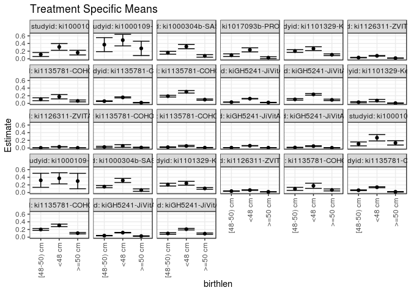

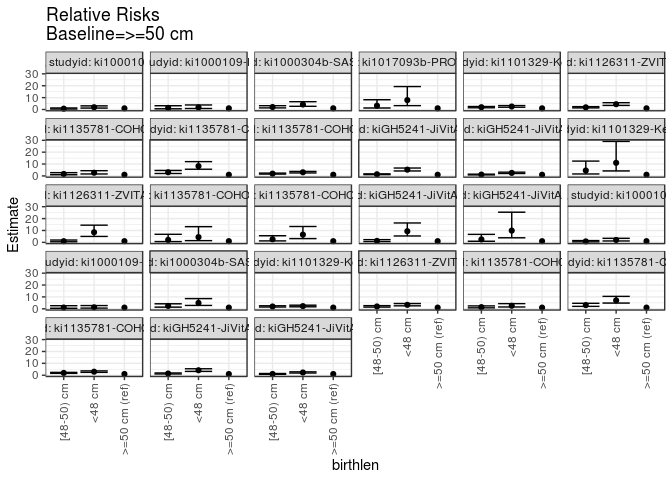

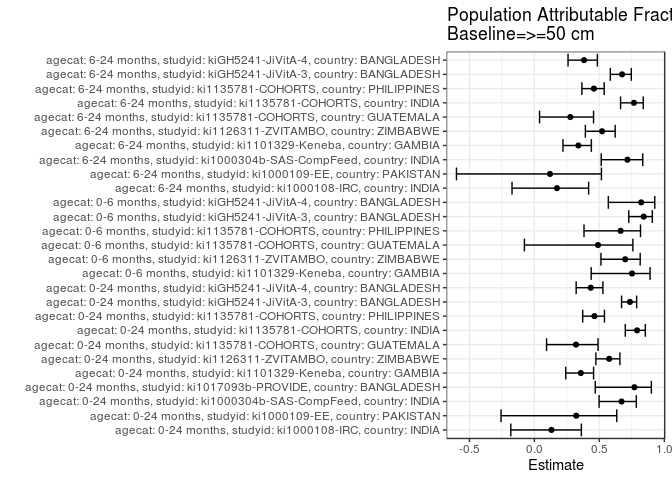

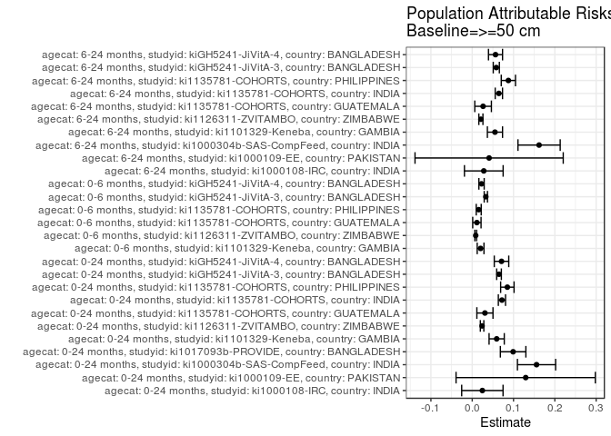

## Results Table

### Parameter: TSM

| agecat | studyid | country | intervention_level | baseline_level | estimate | ci_lower | ci_upper |
| --- | --- | --- | --- | --- | --- | --- | --- |
| 0-24 months | ki1000108-IRC | INDIA | >=50 cm | NA | 0.1621440 | 0.1014039 | 0.2228841 |
| 0-24 months | ki1000108-IRC | INDIA | <48 cm | NA | 0.3103438 | 0.2226173 | 0.3980703 |
| 0-24 months | ki1000108-IRC | INDIA | [48-50) cm | NA | 0.1126776 | 0.0603291 | 0.1650262 |
| 0-24 months | ki1000109-EE | PAKISTAN | >=50 cm | NA | 0.2727273 | 0.0856061 | 0.4598484 |
| 0-24 months | ki1000109-EE | PAKISTAN | <48 cm | NA | 0.4883721 | 0.3381480 | 0.6385962 |
| 0-24 months | ki1000109-EE | PAKISTAN | [48-50) cm | NA | 0.3703704 | 0.1872232 | 0.5535175 |
| 0-24 months | ki1000304b-SAS-CompFeed | INDIA | >=50 cm | NA | 0.0762973 | 0.0438559 | 0.1087387 |
| 0-24 months | ki1000304b-SAS-CompFeed | INDIA | <48 cm | NA | 0.3203675 | 0.2639052 | 0.3768298 |
| 0-24 months | ki1000304b-SAS-CompFeed | INDIA | [48-50) cm | NA | 0.1585770 | 0.1223309 | 0.1948231 |
| 0-24 months | ki1017093b-PROVIDE | BANGLADESH | >=50 cm | NA | 0.0295858 | 0.0040214 | 0.0551502 |
| 0-24 months | ki1017093b-PROVIDE | BANGLADESH | <48 cm | NA | 0.2338710 | 0.1811514 | 0.2865905 |
| 0-24 months | ki1017093b-PROVIDE | BANGLADESH | [48-50) cm | NA | 0.0954064 | 0.0611548 | 0.1296580 |
| 0-24 months | ki1101329-Keneba | GAMBIA | >=50 cm | NA | 0.1064986 | 0.0844232 | 0.1285740 |
| 0-24 months | ki1101329-Keneba | GAMBIA | <48 cm | NA | 0.2657006 | 0.2159494 | 0.3154518 |
| 0-24 months | ki1101329-Keneba | GAMBIA | [48-50) cm | NA | 0.2039161 | 0.1686578 | 0.2391744 |
| 0-24 months | ki1126311-ZVITAMBO | ZIMBABWE | >=50 cm | NA | 0.0175858 | 0.0135071 | 0.0216645 |
| 0-24 months | ki1126311-ZVITAMBO | ZIMBABWE | <48 cm | NA | 0.0782111 | 0.0701547 | 0.0862675 |
| 0-24 months | ki1126311-ZVITAMBO | ZIMBABWE | [48-50) cm | NA | 0.0318952 | 0.0271320 | 0.0366585 |
| 0-24 months | ki1135781-COHORTS | GUATEMALA | >=50 cm | NA | 0.0652845 | 0.0415657 | 0.0890033 |
| 0-24 months | ki1135781-COHORTS | GUATEMALA | <48 cm | NA | 0.1756372 | 0.1179251 | 0.2333493 |
| 0-24 months | ki1135781-COHORTS | GUATEMALA | [48-50) cm | NA | 0.1085523 | 0.0709088 | 0.1461959 |
| 0-24 months | ki1135781-COHORTS | INDIA | >=50 cm | NA | 0.0190462 | 0.0120024 | 0.0260900 |
| 0-24 months | ki1135781-COHORTS | INDIA | <48 cm | NA | 0.1568973 | 0.1433351 | 0.1704595 |
| 0-24 months | ki1135781-COHORTS | INDIA | [48-50) cm | NA | 0.0585216 | 0.0491423 | 0.0679009 |
| 0-24 months | ki1135781-COHORTS | PHILIPPINES | >=50 cm | NA | 0.0990205 | 0.0815830 | 0.1164581 |
| 0-24 months | ki1135781-COHORTS | PHILIPPINES | <48 cm | NA | 0.3023397 | 0.2699997 | 0.3346798 |
| 0-24 months | ki1135781-COHORTS | PHILIPPINES | [48-50) cm | NA | 0.1885142 | 0.1660944 | 0.2109339 |
| 0-24 months | kiGH5241-JiVitA-3 | BANGLADESH | >=50 cm | NA | 0.0233447 | 0.0180833 | 0.0286061 |
| 0-24 months | kiGH5241-JiVitA-3 | BANGLADESH | <48 cm | NA | 0.1230836 | 0.1174892 | 0.1286780 |
| 0-24 months | kiGH5241-JiVitA-3 | BANGLADESH | [48-50) cm | NA | 0.0325968 | 0.0279249 | 0.0372687 |

[output cut: 51 more lines]

### Parameter: E(Y)

| agecat | studyid | country | intervention_level | baseline_level | estimate | ci_lower | ci_upper |
| --- | --- | --- | --- | --- | --- | --- | --- |
| 0-24 months | ki1000108-IRC | INDIA | NA | NA | 0.1867008 | 0.1480272 | 0.2253743 |
| 0-24 months | ki1000109-EE | PAKISTAN | NA | NA | 0.4021739 | 0.3014293 | 0.5029185 |
| 0-24 months | ki1000304b-SAS-CompFeed | INDIA | NA | NA | 0.2320000 | 0.1911686 | 0.2728314 |
| 0-24 months | ki1017093b-PROVIDE | BANGLADESH | NA | NA | 0.1285714 | 0.1037574 | 0.1533855 |
| 0-24 months | ki1101329-Keneba | GAMBIA | NA | NA | 0.1656995 | 0.1471896 | 0.1842095 |
| 0-24 months | ki1126311-ZVITAMBO | ZIMBABWE | NA | NA | 0.0414553 | 0.0381291 | 0.0447815 |
| 0-24 months | ki1135781-COHORTS | GUATEMALA | NA | NA | 0.0960384 | 0.0760175 | 0.1160593 |
| 0-24 months | ki1135781-COHORTS | INDIA | NA | NA | 0.0909777 | 0.0840539 | 0.0979015 |
| 0-24 months | ki1135781-COHORTS | PHILIPPINES | NA | NA | 0.1840632 | 0.1702782 | 0.1978483 |
| 0-24 months | kiGH5241-JiVitA-3 | BANGLADESH | NA | NA | 0.0882064 | 0.0843238 | 0.0920889 |
| 0-24 months | kiGH5241-JiVitA-4 | BANGLADESH | NA | NA | 0.1635066 | 0.1508784 | 0.1761348 |
| 0-6 months | ki1101329-Keneba | GAMBIA | NA | NA | 0.0269382 | 0.0188017 | 0.0350748 |
| 0-6 months | ki1126311-ZVITAMBO | ZIMBABWE | NA | NA | 0.0120991 | 0.0102697 | 0.0139286 |
| 0-6 months | ki1135781-COHORTS | GUATEMALA | NA | NA | 0.0230583 | 0.0128042 | 0.0333123 |
| 0-6 months | ki1135781-COHORTS | PHILIPPINES | NA | NA | 0.0237154 | 0.0183020 | 0.0291288 |
| 0-6 months | kiGH5241-JiVitA-3 | BANGLADESH | NA | NA | 0.0391815 | 0.0366710 | 0.0416921 |
| 0-6 months | kiGH5241-JiVitA-4 | BANGLADESH | NA | NA | 0.0274281 | 0.0217023 | 0.0331538 |
| 6-24 months | ki1000108-IRC | INDIA | NA | NA | 0.1611253 | 0.1246376 | 0.1976130 |
| 6-24 months | ki1000109-EE | PAKISTAN | NA | NA | 0.3409091 | 0.2413043 | 0.4405139 |
| 6-24 months | ki1000304b-SAS-CompFeed | INDIA | NA | NA | 0.2260174 | 0.1899444 | 0.2620905 |
| 6-24 months | ki1101329-Keneba | GAMBIA | NA | NA | 0.1627438 | 0.1439757 | 0.1815119 |
| 6-24 months | ki1126311-ZVITAMBO | ZIMBABWE | NA | NA | 0.0403066 | 0.0365568 | 0.0440563 |
| 6-24 months | ki1135781-COHORTS | GUATEMALA | NA | NA | 0.0950413 | 0.0736937 | 0.1163890 |
| 6-24 months | ki1135781-COHORTS | INDIA | NA | NA | 0.0841713 | 0.0772407 | 0.0911019 |
| 6-24 months | ki1135781-COHORTS | PHILIPPINES | NA | NA | 0.1910032 | 0.1764432 | 0.2055633 |
| 6-24 months | kiGH5241-JiVitA-3 | BANGLADESH | NA | NA | 0.0863564 | 0.0817075 | 0.0910053 |
| 6-24 months | kiGH5241-JiVitA-4 | BANGLADESH | NA | NA | 0.1475190 | 0.1356672 | 0.1593708 |

### Parameter: RR

| agecat | studyid | country | intervention_level | baseline_level | estimate | ci_lower | ci_upper |
| --- | --- | --- | --- | --- | --- | --- | --- |
| 0-24 months | ki1000108-IRC | INDIA | >=50 cm | >=50 cm | 1.0000000 | 1.0000000 | 1.000000 |
| 0-24 months | ki1000108-IRC | INDIA | <48 cm | >=50 cm | 1.9140010 | 1.1993808 | 3.054409 |
| 0-24 months | ki1000108-IRC | INDIA | [48-50) cm | >=50 cm | 0.6949232 | 0.3826343 | 1.262088 |
| 0-24 months | ki1000109-EE | PAKISTAN | >=50 cm | >=50 cm | 1.0000000 | 1.0000000 | 1.000000 |
| 0-24 months | ki1000109-EE | PAKISTAN | <48 cm | >=50 cm | 1.7906977 | 0.8442525 | 3.798151 |
| 0-24 months | ki1000109-EE | PAKISTAN | [48-50) cm | >=50 cm | 1.3580247 | 0.5829181 | 3.163791 |
| 0-24 months | ki1000304b-SAS-CompFeed | INDIA | >=50 cm | >=50 cm | 1.0000000 | 1.0000000 | 1.000000 |
| 0-24 months | ki1000304b-SAS-CompFeed | INDIA | <48 cm | >=50 cm | 4.1989351 | 2.6872607 | 6.560977 |
| 0-24 months | ki1000304b-SAS-CompFeed | INDIA | [48-50) cm | >=50 cm | 2.0784087 | 1.3448032 | 3.212204 |
| 0-24 months | ki1017093b-PROVIDE | BANGLADESH | >=50 cm | >=50 cm | 1.0000000 | 1.0000000 | 1.000000 |
| 0-24 months | ki1017093b-PROVIDE | BANGLADESH | <48 cm | >=50 cm | 7.9048387 | 3.2364549 | 19.307074 |
| 0-24 months | ki1017093b-PROVIDE | BANGLADESH | [48-50) cm | >=50 cm | 3.2247350 | 1.2651132 | 8.219751 |
| 0-24 months | ki1101329-Keneba | GAMBIA | >=50 cm | >=50 cm | 1.0000000 | 1.0000000 | 1.000000 |
| 0-24 months | ki1101329-Keneba | GAMBIA | <48 cm | >=50 cm | 2.4948740 | 1.8893591 | 3.294448 |
| 0-24 months | ki1101329-Keneba | GAMBIA | [48-50) cm | >=50 cm | 1.9147302 | 1.4634546 | 2.505163 |
| 0-24 months | ki1126311-ZVITAMBO | ZIMBABWE | >=50 cm | >=50 cm | 1.0000000 | 1.0000000 | 1.000000 |
| 0-24 months | ki1126311-ZVITAMBO | ZIMBABWE | <48 cm | >=50 cm | 4.4474001 | 3.4508553 | 5.731729 |
| 0-24 months | ki1126311-ZVITAMBO | ZIMBABWE | [48-50) cm | >=50 cm | 1.8136921 | 1.3765548 | 2.389646 |
| 0-24 months | ki1135781-COHORTS | GUATEMALA | >=50 cm | >=50 cm | 1.0000000 | 1.0000000 | 1.000000 |
| 0-24 months | ki1135781-COHORTS | GUATEMALA | <48 cm | >=50 cm | 2.6903352 | 1.6513401 | 4.383048 |
| 0-24 months | ki1135781-COHORTS | GUATEMALA | [48-50) cm | >=50 cm | 1.6627578 | 1.0061320 | 2.747913 |
| 0-24 months | ki1135781-COHORTS | INDIA | >=50 cm | >=50 cm | 1.0000000 | 1.0000000 | 1.000000 |
| 0-24 months | ki1135781-COHORTS | INDIA | <48 cm | >=50 cm | 8.2377299 | 5.6368876 | 12.038593 |
| 0-24 months | ki1135781-COHORTS | INDIA | [48-50) cm | >=50 cm | 3.0726162 | 2.0543461 | 4.595608 |
| 0-24 months | ki1135781-COHORTS | PHILIPPINES | >=50 cm | >=50 cm | 1.0000000 | 1.0000000 | 1.000000 |
| 0-24 months | ki1135781-COHORTS | PHILIPPINES | <48 cm | >=50 cm | 3.0533034 | 2.4857163 | 3.750493 |
| 0-24 months | ki1135781-COHORTS | PHILIPPINES | [48-50) cm | >=50 cm | 1.9037885 | 1.5402200 | 2.353177 |
| 0-24 months | kiGH5241-JiVitA-3 | BANGLADESH | >=50 cm | >=50 cm | 1.0000000 | 1.0000000 | 1.000000 |
| 0-24 months | kiGH5241-JiVitA-3 | BANGLADESH | <48 cm | >=50 cm | 5.2724428 | 4.1896160 | 6.635132 |
| 0-24 months | kiGH5241-JiVitA-3 | BANGLADESH | [48-50) cm | >=50 cm | 1.3963246 | 1.0956539 | 1.779506 |

[output cut: 51 more lines]

### Parameter: PAR

| agecat | studyid | country | intervention_level | baseline_level | estimate | ci_lower | ci_upper |
| --- | --- | --- | --- | --- | --- | --- | --- |
| 0-24 months | ki1000108-IRC | INDIA | >=50 cm | NA | 0.0245567 | -0.0255093 | 0.0746228 |
| 0-24 months | ki1000109-EE | PAKISTAN | >=50 cm | NA | 0.1294466 | -0.0391292 | 0.2980225 |
| 0-24 months | ki1000304b-SAS-CompFeed | INDIA | >=50 cm | NA | 0.1557027 | 0.1094556 | 0.2019498 |
| 0-24 months | ki1017093b-PROVIDE | BANGLADESH | >=50 cm | NA | 0.0989856 | 0.0681034 | 0.1298678 |
| 0-24 months | ki1101329-Keneba | GAMBIA | >=50 cm | NA | 0.0592009 | 0.0408156 | 0.0775862 |
| 0-24 months | ki1126311-ZVITAMBO | ZIMBABWE | >=50 cm | NA | 0.0238695 | 0.0196401 | 0.0280988 |
| 0-24 months | ki1135781-COHORTS | GUATEMALA | >=50 cm | NA | 0.0307539 | 0.0112286 | 0.0502792 |
| 0-24 months | ki1135781-COHORTS | INDIA | >=50 cm | NA | 0.0719315 | 0.0632284 | 0.0806345 |
| 0-24 months | ki1135781-COHORTS | PHILIPPINES | >=50 cm | NA | 0.0850427 | 0.0687884 | 0.1012970 |
| 0-24 months | kiGH5241-JiVitA-3 | BANGLADESH | >=50 cm | NA | 0.0648617 | 0.0592173 | 0.0705060 |
| 0-24 months | kiGH5241-JiVitA-4 | BANGLADESH | >=50 cm | NA | 0.0709134 | 0.0534049 | 0.0884219 |
| 0-6 months | ki1101329-Keneba | GAMBIA | >=50 cm | NA | 0.0202448 | 0.0120697 | 0.0284199 |
| 0-6 months | ki1126311-ZVITAMBO | ZIMBABWE | >=50 cm | NA | 0.0084584 | 0.0062871 | 0.0106296 |
| 0-6 months | ki1135781-COHORTS | GUATEMALA | >=50 cm | NA | 0.0112935 | 0.0012027 | 0.0213844 |
| 0-6 months | ki1135781-COHORTS | PHILIPPINES | >=50 cm | NA | 0.0157367 | 0.0097173 | 0.0217561 |
| 0-6 months | kiGH5241-JiVitA-3 | BANGLADESH | >=50 cm | NA | 0.0329619 | 0.0289956 | 0.0369281 |
| 0-6 months | kiGH5241-JiVitA-4 | BANGLADESH | >=50 cm | NA | 0.0225540 | 0.0161589 | 0.0289490 |
| 6-24 months | ki1000108-IRC | INDIA | >=50 cm | NA | 0.0279905 | -0.0188313 | 0.0748123 |
| 6-24 months | ki1000109-EE | PAKISTAN | >=50 cm | NA | 0.0409091 | -0.1384651 | 0.2202833 |
| 6-24 months | ki1000304b-SAS-CompFeed | INDIA | >=50 cm | NA | 0.1618488 | 0.1107658 | 0.2129319 |
| 6-24 months | ki1101329-Keneba | GAMBIA | >=50 cm | NA | 0.0550459 | 0.0366991 | 0.0733927 |
| 6-24 months | ki1126311-ZVITAMBO | ZIMBABWE | >=50 cm | NA | 0.0209844 | 0.0160435 | 0.0259253 |
| 6-24 months | ki1135781-COHORTS | GUATEMALA | >=50 cm | NA | 0.0263104 | 0.0062122 | 0.0464086 |
| 6-24 months | ki1135781-COHORTS | INDIA | >=50 cm | NA | 0.0645041 | 0.0556501 | 0.0733580 |
| 6-24 months | ki1135781-COHORTS | PHILIPPINES | >=50 cm | NA | 0.0875093 | 0.0702611 | 0.1047575 |
| 6-24 months | kiGH5241-JiVitA-3 | BANGLADESH | >=50 cm | NA | 0.0582900 | 0.0508976 | 0.0656823 |
| 6-24 months | kiGH5241-JiVitA-4 | BANGLADESH | >=50 cm | NA | 0.0563825 | 0.0393664 | 0.0733987 |

### Parameter: PAF

| agecat | studyid | country | intervention_level | baseline_level | estimate | ci_lower | ci_upper |
| --- | --- | --- | --- | --- | --- | --- | --- |
| 0-24 months | ki1000108-IRC | INDIA | >=50 cm | NA | 0.1315300 | -0.1815299 | 0.3616411 |
| 0-24 months | ki1000109-EE | PAKISTAN | >=50 cm | NA | 0.3218673 | -0.2569606 | 0.6341461 |
| 0-24 months | ki1000304b-SAS-CompFeed | INDIA | >=50 cm | NA | 0.6711322 | 0.4979578 | 0.7845719 |
| 0-24 months | ki1017093b-PROVIDE | BANGLADESH | >=50 cm | NA | 0.7698882 | 0.4684627 | 0.9003806 |
| 0-24 months | ki1101329-Keneba | GAMBIA | >=50 cm | NA | 0.3572788 | 0.2411908 | 0.4556069 |
| 0-24 months | ki1126311-ZVITAMBO | ZIMBABWE | >=50 cm | NA | 0.5757885 | 0.4733703 | 0.6582886 |
| 0-24 months | ki1135781-COHORTS | GUATEMALA | >=50 cm | NA | 0.3202251 | 0.0938841 | 0.4900279 |
| 0-24 months | ki1135781-COHORTS | INDIA | >=50 cm | NA | 0.7906499 | 0.6997751 | 0.8540179 |
| 0-24 months | ki1135781-COHORTS | PHILIPPINES | >=50 cm | NA | 0.4620298 | 0.3718717 | 0.5392470 |
| 0-24 months | kiGH5241-JiVitA-3 | BANGLADESH | >=50 cm | NA | 0.7353399 | 0.6709351 | 0.7871393 |
| 0-24 months | kiGH5241-JiVitA-4 | BANGLADESH | >=50 cm | NA | 0.4337035 | 0.3215223 | 0.5273364 |
| 0-6 months | ki1101329-Keneba | GAMBIA | >=50 cm | NA | 0.7515264 | 0.4371398 | 0.8903118 |
| 0-6 months | ki1126311-ZVITAMBO | ZIMBABWE | >=50 cm | NA | 0.6990889 | 0.5122972 | 0.8143388 |
| 0-6 months | ki1135781-COHORTS | GUATEMALA | >=50 cm | NA | 0.4897833 | -0.0767738 | 0.7582398 |
| 0-6 months | ki1135781-COHORTS | PHILIPPINES | >=50 cm | NA | 0.6635638 | 0.3819918 | 0.8168482 |
| 0-6 months | kiGH5241-JiVitA-3 | BANGLADESH | >=50 cm | NA | 0.8412604 | 0.7266286 | 0.9078241 |
| 0-6 months | kiGH5241-JiVitA-4 | BANGLADESH | >=50 cm | NA | 0.8222956 | 0.5691586 | 0.9267042 |
| 6-24 months | ki1000108-IRC | INDIA | >=50 cm | NA | 0.1737186 | -0.1721383 | 0.4175253 |
| 6-24 months | ki1000109-EE | PAKISTAN | >=50 cm | NA | 0.1200000 | -0.5999326 | 0.5159796 |
| 6-24 months | ki1000304b-SAS-CompFeed | INDIA | >=50 cm | NA | 0.7160899 | 0.5143999 | 0.8340097 |
| 6-24 months | ki1101329-Keneba | GAMBIA | >=50 cm | NA | 0.3382367 | 0.2199357 | 0.4385967 |
| 6-24 months | ki1126311-ZVITAMBO | ZIMBABWE | >=50 cm | NA | 0.5206192 | 0.3923446 | 0.6218154 |
| 6-24 months | ki1135781-COHORTS | GUATEMALA | >=50 cm | NA | 0.2768311 | 0.0396424 | 0.4554391 |
| 6-24 months | ki1135781-COHORTS | INDIA | >=50 cm | NA | 0.7663429 | 0.6633895 | 0.8378077 |
| 6-24 months | ki1135781-COHORTS | PHILIPPINES | >=50 cm | NA | 0.4581561 | 0.3655473 | 0.5372471 |
| 6-24 months | kiGH5241-JiVitA-3 | BANGLADESH | >=50 cm | NA | 0.6749933 | 0.5843985 | 0.7458398 |
| 6-24 months | kiGH5241-JiVitA-4 | BANGLADESH | >=50 cm | NA | 0.3822052 | 0.2591194 | 0.4848422 |